# Task 2

Ray Hunter

2023-02-12

```r
knitr::opts_chunk$set(echo=TRUE, warning=FALSE, message=FALSE,  results=FALSE)
library(purrr)
library(tidyverse)
library(janitor)
library(Metrics)
library(cowplot)
library(here)
library(kableExtra)
library(Metrics)
```

## Task 2

#### Introduction:

The purpose this task is to create a model that accurately fits lizard phenotype traits to a data set of lizard observations. To do this, we use a non linear least squares model to estimate the parameters of a snout length to weight model. All data was collected in New Mexico from 1989-2006 across twenty different species (Ligthfoot and Whitford, 2020).

**Dats Source:** Lightfoot, D. and W.G. Whitford. 2020. Lizard pitfall trap data from 11 NPP study locations at the Jornada Basin LTER site, 1989-2006 ver 37. Environmental Data Initiative. https://doi.org/10.6073/pasta/4a6e258fb49c31e222ecbbcfd128967f

#### NLS Model 1 Creation

```r
#reading in data and wrangling
mdl1_data<-  read_csv(here("data", "lizards.csv")) %>%
  clean_names() %>%
  #taking th log of values
  mutate(log_weight = log(weight), log_length = log(sv_length))


mdl1_data$sex[mdl1_data$sex=="F"] <- "female"
mdl1_data$sex[mdl1_data$sex=="M"] <- "male"
```

**1:** Model equation for lizard weigth ($W$) and snout-vent length ($SVL$) where $a$ and $b$ are parameters that need to be fitted.

$$W =a(SVL)^b$$

**2:** Because the data has an exponential nature, we need to use a log transformation to create a linear model using ordinary least squares (OLS). This then gives us the intercepts and slope coefficient values of the model that can be applied to the original equation to create a non linear least squares (NLS) model.*

$$log(W)= log(a) +
b*log(SVL)$$

```r
#running an OLS model
guess_mod1 <- lm(log_weight ~log_length, data = mdl1_data)


#creating a funciton that calculates the original equation
func1<-function(a,b,length){
 out= a*(length^b)
return(out)
}




#creating and NLS model
nls_mdl1=nls(weight ~func1(a,b, sv_length),
                  data=mdl1_data,
                  start=list(a=exp(-8.25), b=2.479417),
                  trace=TRUE)
summary(nls_mdl1)
```

**3:** We then extract the coefficients from the OLS model and apply them to a function that can be used to create a non-linear least regressions NLS model using the original equation.

$$W = e^{-8.25} (SVL)^{2.48}$$

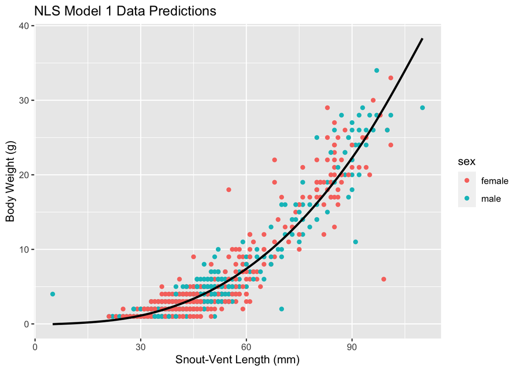

*Figure 1*: Non linear least squars (NLS) model showing the relation ship between snout-vent length (mm) and predicted body weigth (g) fitted to actual body weight measurements for all lizards.

```r
#creating a new data set with model predicitions
mdl1_predict<-mdl1_data %>%
  mutate(predict=predict(nls_mdl1,newdata=.))

#visualizing the NLS
ggplot1 <- ggplot(data=mdl1_predict)+
  geom_point(aes(x=sv_length,y=weight,colour = sex)) +
  ggtitle("NLS Model 1 Data Predictions") +
 labs(x = "Snout-Vent Length (mm)", y = "Body Weight (g)")+

    geom_smooth(aes(x=sv_length,y=predict), color='black')

ggplot1
```

```r
#### NLS model output

broom::tidy(nls_mdl1) %>%
  kable(caption = "Table 1: NLS model showing the parameter estimates for *a* an *b*. These parametere are used in the model to predict body mass (g) from snot-vent length (mm).") %>%
  kable_material()
```

Table 1: NLS model showing the parameter estimates for *a* an *b*. These parametere are used in the model to predict body mass (g) from snot-vent length (mm).

| term | estimate | std.error | statistic | p.value |
| --- | --- | --- | --- | --- |
| a | 0.0001073 | 0.0000091 | 11.77374 | 0 |
| b | 2.7209865 | 0.0196796 | 138.26425 | 0 |